# Cluster Trees

Jacob C. Cooper

14 September 2021

# 1 Introduction

This is intended to create nice, more readable trees for these analyses. I report some results from *k-means clustering* here, but **note** that all trees are derived from *hierarchical clustering* exercises. Groups for the trees are from the ‘elbow’ method and from viewing major clades *by the author*, both of which are non-exact heuristics that are subject to observer interpretation.

```r
library(tidyverse)
library(phytools)
library(data.table)
# for first time install use:

# BiocManager::install("ggtree")

library(tidytree)
library(ggtree)
library(RColorBrewer) # palette pulled from website
```

## Note on KMeans

The algorithms used for `kmeans` clustering uses ten iterations to determine cluster assignments based on a provided *k* value. As this is an algorithm that runs repeatedly, results are not always identical between runs. Therefore, results shown here for `kmeans` are not necessarily identical to files provided or assignments determined during other runs of the algorithm. This is another reason why `kmeans` was used in conjunction with `hclust`, and why general patterns and topologies (including patterns in what regions are uncertain) are so important.

# 2 Phylogenetic Trees

First, we must get the names of all species.

```r
# files defined for trees
```

```r
x.colors=c('#1b9e77', # greenish
           '#000000', # black
           '#d95f02', # orangish
           '#7570b3') # purple

# group go up to 9; rep this so adjacent groups are different colors

x.colors=rep(x.colors,2)

# load coordinate data

meta.x=read.csv(paste0(filepath,"locality_metadata.csv"))
colnames(meta.x)[1]="Region"
```

# 2.1 Genus

```r
csvs=list.files(filepath,pattern="*.csv")
csvs=paste0(filepath,csvs)

z.csv=read.csv(csvs[csvs%like%"Genus"&csvs%like%"Cooper"])
y.csv=read.csv(csvs[csvs%like%"Genus"&csvs%like%"Bowie"])
x.csv=read.csv(csvs[csvs%like%"Genus"&csvs%like%"Dowsett"])

colnames(x.csv)=c("Region","Dowsett")
colnames(y.csv)=c("Region","Bowie")
colnames(z.csv)=c("Region","Cooper")

genus_clusters=x.csv%>%inner_join(y.csv,by='Region')%>%
  inner_join(z.csv,by='Region')%>%
  inner_join(meta.x,by='Region')

write.csv(genus_clusters,file=paste0(filepath,"genus_cluster.csv"),
          row.names = F,quote = F)
```

```r
# how are regions split up?
# comparison Bowie and Dowsett

y=table(genus_clusters[,2:3])
print(y)
```

```
##        Bowie
## Dowsett  1  2  3  4
##       1 21  1  0  0
##       2  0  2  4  0
##       3  1  8  0  0
##       4  0  0  0  5
```

```r
d.b.sub=genus_clusters%>%select(Region,Dowsett,Bowie)%>%unique()
d.b.sub[order(d.b.sub$Dowsett),]
```

```
##                 Region Dowsett Bowie
## 12         S Eth-N Ken       1     2
## 20               Taita       1     1
## 23                Nguu       1     1
## 24               Nguru       1     1
## 25             Ukaguru       1     1
## 26              Rubeho       1     1
## 27             Uluguru       1     1
## 28            Udzungwa       1     1
## 29  Southern Highlands       1     1
## 30               Nyika       1     1
## 31           Kaningina       1     1
## 32        Dedza-Salima       1     1
## 33               Zomba       1     1
## 34              Thyolo       1     1
```

[output cut: 28 more lines]

*Note* that Bowie and Dowsett here place Lendu with the Cameroon Highlands, not the Lacustrine [Albertine] Rift!

```r
d.b.sub=genus_clusters%>%select(Region,Dowsett,Cooper)%>%unique()
d.b.sub[order(d.b.sub$Dowsett),]
```

[output not shown]

```r
z=read.tree(files[files%like%"Genus"&files%like%"Cooper"])
y=read.tree(files[files%like%"Genus"&files%like%"Bowie"])
x=read.tree(files[files%like%"Genus"&files%like%"Dowsett"])

z$tip.label=gsub("_"," ",z$tip.label)
x$tip.label=gsub("_"," ",x$tip.label)
y$tip.label=gsub("_"," ",y$tip.label)

x="fortify"(x)
y="fortify"(y)
z="fortify"(z)

y$x=y$x+max(x$x)+1
z$x=z$x+max(y$x)+1

dd=bind_rows(x,y,z)%>%
  filter(!is.na(label))
```

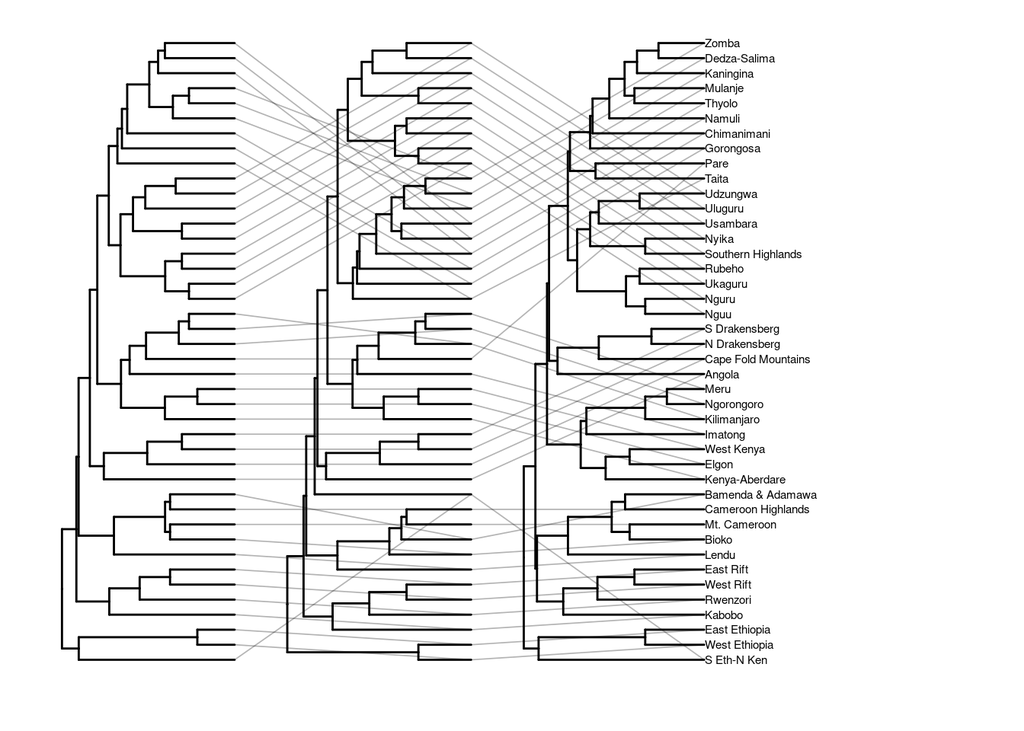

```r
p1=ggtree(x,layout='rectangular')# leftmost tree
p2=geom_tree(data=y) # middle tree
p3=geom_tree(data=z) # rightmost tree
p4=geom_tiplab(data=z,size=2)
p5=geom_line(aes(x,y,group=label),data=dd,alpha=.3,size=0.3)
p6=xlim(c(0,max(z$x)+5))
p7=ylim(c(-0.5,max(z$y)))

plot1=p1+p2+p3+p4+p5+p6+p7
plot1
```

```r
ggsave(paste0(filepath,"genus_compared.jpg"),
       plot = plot1,dpi = 400)
```

# 2.2 Superspecies

```r
z.csv=read.csv(csvs[csvs%like%"Superspecies"&csvs%like%"Cooper"])
y.csv=read.csv(csvs[csvs%like%"Superspecies"&csvs%like%"Bowie"])
x.csv=read.csv(csvs[csvs%like%"Superspecies"&csvs%like%"Dowsett"])

colnames(x.csv)=c("Region","Dowsett")
colnames(y.csv)=c("Region","Bowie")
colnames(z.csv)=c("Region","Cooper")

subset_clusters=x.csv%>%inner_join(y.csv,by='Region')%>%
  inner_join(z.csv,by='Region')%>%
  inner_join(meta.x,by='Region')

write.csv(subset_clusters,file=paste0(filepath,"superspecies_cluster.csv"),
          row.names = F,quote = F)
```

```r
d.b.sub=subset_clusters%>%select(Region,Dowsett,Bowie)%>%unique()
d.b.sub[order(d.b.sub$Dowsett),]
```

```
##                 Region Dowsett Bowie
## 31           Kaningina       1     1
## 32        Dedza-Salima       1     1
## 33               Zomba       1     1
## 34              Thyolo       1     1
## 35             Mulanje       1     1
## 36              Namuli       1    12
## 5                Lendu       2    10
## 9               Kabobo       2    16
## 14               Elgon       3     2
## 15          West Kenya       3     2
## 16      Kenya-Aberdare       3     2
## 1                Bioko       4     4
## 2         Mt. Cameroon       4     4
## 3   Cameroon Highlands       4     4
```

[output cut: 28 more lines]

```r
d.b.sub=subset_clusters%>%select(Region,Dowsett,Cooper)%>%unique()
d.b.sub[order(d.b.sub$Cooper),]
```

```
##                 Region Dowsett Cooper
## 31           Kaningina       1      1
## 32        Dedza-Salima       1      1
## 33               Zomba       1      1
## 34              Thyolo       1      1
## 35             Mulanje       1      1
## 36              Namuli       1      1
## 10       West Ethiopia      13      2
## 11       East Ethiopia      13      2
## 13             Imatong       5      3
## 14               Elgon       3      3
## 15          West Kenya       3      3
## 16      Kenya-Aberdare       3      3
## 17          Ngorongoro      11      3
## 18                Meru      11      3
```

[output cut: 28 more lines]

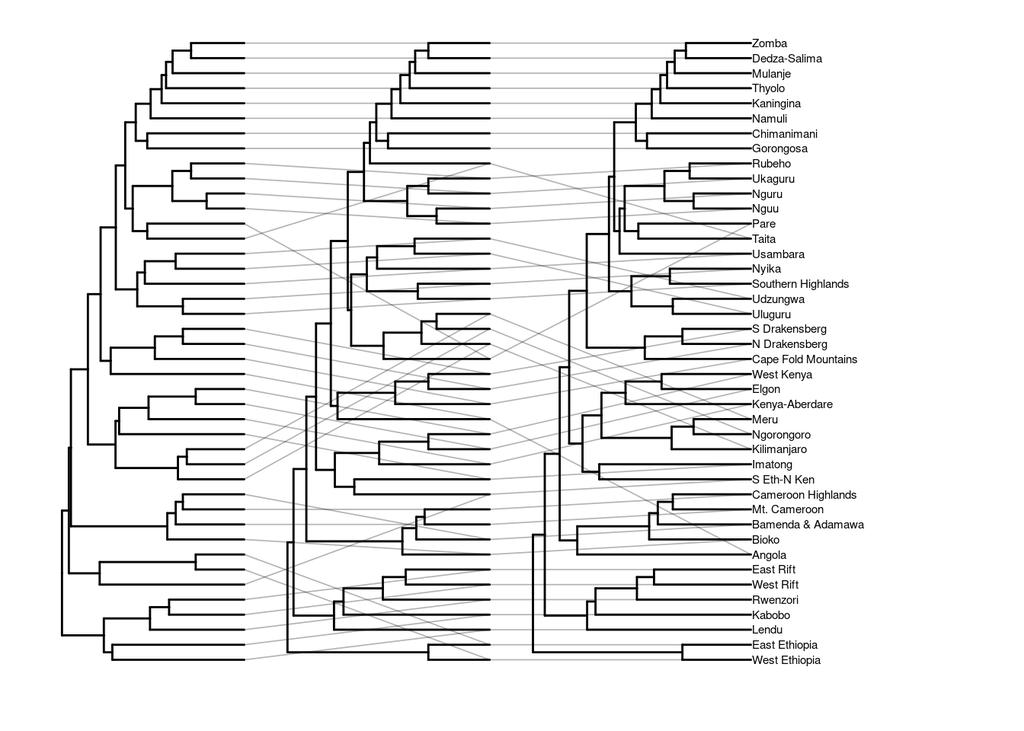

```r
z=read.tree(files[files%like%"Superspecies"&files%like%"Cooper"])
y=read.tree(files[files%like%"Superspecies"&files%like%"Bowie"])
x=read.tree(files[files%like%"Superspecies"&files%like%"Dowsett"])

z$tip.label=gsub("_"," ",z$tip.label)
x$tip.label=gsub("_"," ",x$tip.label)
y$tip.label=gsub("_"," ",y$tip.label)

x=fortify(x)
y=fortify(y)
z=fortify(z)

y$x=y$x+max(x$x)+1
z$x=z$x+max(y$x)+1

dd=bind_rows(x,y,z)%>%
  filter(!is.na(label))

p1=ggtree(x,layout='rectangular')
p2=geom_tree(data=y)
p3=geom_tree(data=z)
p4=geom_tiplab(data=z,size=2)
p5=geom_line(aes(x,y,group=label),data=dd,alpha=.3,size=0.3)
p6=xlim(c(0,max(z$x)+5))
p7=ylim(c(-0.5,max(z$y)))

plot1=p1+p2+p3+p4+p5+p6+p7
plot1
```

```r
ggsave(paste0(filepath,"superspecies_compared.jpg"),
       plot = plot1,dpi = 400)
```

# 2.3 Species

```r
z.csv=read.csv(csvs[csvs%like%"Species"&csvs%like%"Cooper"])
y.csv=read.csv(csvs[csvs%like%"Species"&csvs%like%"Bowie"])
x.csv=read.csv(csvs[csvs%like%"Species"&csvs%like%"Dowsett"])

colnames(x.csv)=c("Region","Dowsett")
colnames(y.csv)=c("Region","Bowie")
colnames(z.csv)=c("Region","Cooper")

subset_clusters=x.csv%>%inner_join(y.csv,by='Region')%>%
  inner_join(z.csv,by='Region')%>%
  inner_join(meta.x,by='Region')

write.csv(subset_clusters,file=paste0(filepath,"Species_cluster.csv"),
          row.names = F,quote = F)
```

```
##        Bowie
## Dowsett 1 2 3 4 5 6 7 8 9 10
##       1 6 0 0 0 0 0 8 3 0  0
##       2 0 0 0 0 0 0 0 0 0  5
##       3 0 4 1 0 2 0 0 0 3  0
##       4 0 0 0 4 0 0 0 0 0  0
##       5 1 0 1 0 0 4 0 0 0  0
```

```
##      Cooper
## Bowie 1 2 3 4 5 6 7 8 9 10
##    1  6 0 0 0 1 0 0 0 0  0
##    2  0 0 4 0 0 0 0 0 0  0
##    3  0 0 0 0 1 0 0 1 0  0
##    4  0 0 0 4 0 0 0 0 0  0
##    5  0 2 0 0 0 0 0 0 0  0
##    6  0 0 0 0 1 3 0 0 0  0
##    7  1 0 0 0 0 0 4 0 3  0
##    8  0 0 0 0 1 0 0 0 2  0
##    9  0 0 0 0 0 0 0 0 3  0
##    10 0 0 0 0 0 0 0 0 0  5
```

```r
d.b.sub=subset_clusters%>%select(Region,Dowsett,Bowie)%>%unique()
d.b.sub[order(d.b.sub$Dowsett),]
```

```
##                 Region Dowsett Bowie
## 20               Taita       1     8
## 21                Pare       1     8
## 22            Usambara       1     8
## 23                Nguu       1     7
## 24               Nguru       1     7
## 25             Ukaguru       1     7
## 26              Rubeho       1     7
## 27             Uluguru       1     7
## 28            Udzungwa       1     7
## 29  Southern Highlands       1     7
## 30               Nyika       1     7
## 31           Kaningina       1     1
## 32        Dedza-Salima       1     1
## 33               Zomba       1     1
```

[output cut: 28 more lines]

Now, to plot the tree to view topology and to determine best format:

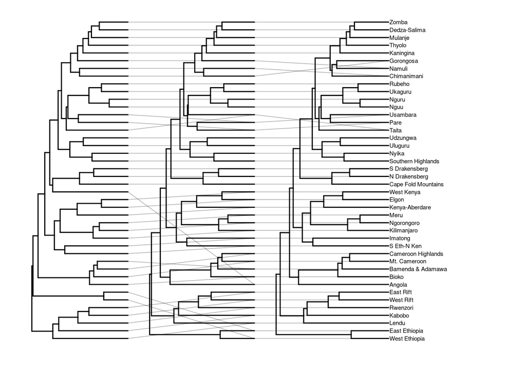

```r
z=read.tree(files[files%like%"Species"&files%like%"Cooper"])
y=read.tree(files[files%like%"Species"&files%like%"Bowie"])
x=read.tree(files[files%like%"Species"&files%like%"Dowsett"])

z$tip.label=gsub("_"," ",z$tip.label)
x$tip.label=gsub("_"," ",x$tip.label)
y$tip.label=gsub("_"," ",y$tip.label)

x=fortify(x)
y=fortify(y)
z=fortify(z)

y$x=y$x+max(x$x)+1
z$x=z$x+max(y$x)+1

dd=bind_rows(x,y,z)%>%
  filter(!is.na(label))

p1=ggtree(x,layout='rectangular')
p2=geom_tree(data=y)
p3=geom_tree(data=z)
p4=geom_tiplab(data=z,size=2)
p5=geom_line(aes(x,y,group=label),data=dd,alpha=.3,size=0.3)
p6=xlim(c(0,max(z$x)+5))
p7=ylim(c(-0.5,max(z$y)))

plot1=p1+p2+p3+p4+p5+p6+p7
plot1
```

```r
ggsave(paste0(filepath,"species_compared.jpg"),
       plot = plot1,dpi = 400)
```

# 2.4 Group

```r
z.csv=read.csv(csvs[csvs%like%"Group"&csvs%like%"Cooper"])
y.csv=read.csv(csvs[csvs%like%"Group"&csvs%like%"Bowie"])
x.csv=read.csv(csvs[csvs%like%"Group"&csvs%like%"Dowsett"])

colnames(x.csv)=c("Region","Dowsett")
colnames(y.csv)=c("Region","Bowie")
colnames(z.csv)=c("Region","Cooper")

subset_clusters=x.csv%>%inner_join(y.csv,by='Region')%>%
  inner_join(z.csv,by='Region')%>%
  inner_join(meta.x,by='Region')

write.csv(subset_clusters,file=paste0(filepath,"Group_cluster.csv"),
          row.names = F,quote = F)
```

```
##        Bowie
## Dowsett 1 2 3
##      1  7 0 0
##      2  1 2 1
##      3  0 3 0
##      4  4 0 0
##      5  0 2 0
##      6  3 0 0
##      7  7 0 0
##      8  2 3 0
##      9  3 0 0
##      10 0 0 4
```

```
##      Cooper
## Bowie 1 2 3 4 5 6 7 8 9 10 11 12 13 14 15 16
##     1 3 0 0 4 2 3 4 0 3  0  0  3  1  2  2  0
##     2 0 3 2 0 0 0 0 2 0  0  3  0  0  0  0  0
##     3 0 0 0 0 0 0 0 0 0  2  0  0  0  0  0  3
```

```r
d.b.sub=subset_clusters%>%select(Region,Dowsett,Bowie)%>%unique()
d.b.sub[order(d.b.sub$Dowsett),]
```

```
##                 Region Dowsett Bowie
## 32        Dedza-Salima       1     1
## 33               Zomba       1     1
## 34              Thyolo       1     1
## 35             Mulanje       1     1
## 36              Namuli       1     1
## 37           Gorongosa       1     1
## 38         Chimanimani       1     1
## 5                Lendu       2     3
## 12         S Eth-N Ken       2     2
## 13             Imatong       2     2
## 42              Angola       2     1
## 14               Elgon       3     2
## 15          West Kenya       3     2
## 16      Kenya-Aberdare       3     2
```

[output cut: 28 more lines]

Now, to plot the tree to view topology and to determine best format:

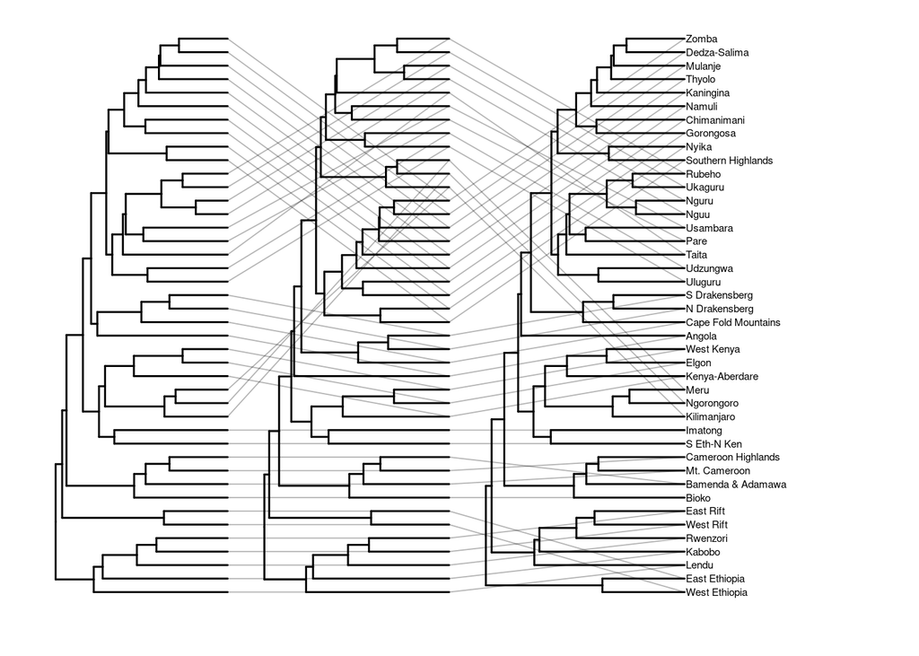

```r
z=read.tree(files[files%like%"Group"&files%like%"Cooper"])
y=read.tree(files[files%like%"Group"&files%like%"Bowie"])
x=read.tree(files[files%like%"Group"&files%like%"Dowsett"])

z$tip.label=gsub("_"," ",z$tip.label)
x$tip.label=gsub("_"," ",x$tip.label)
y$tip.label=gsub("_"," ",y$tip.label)

x=fortify(x)
y=fortify(y)
z=fortify(z)

y$x=y$x+max(x$x)+1
z$x=z$x+max(y$x)+1

dd=bind_rows(x,y,z)%>%
  filter(!is.na(label))

p1=ggtree(x,layout='rectangular')
p2=geom_tree(data=y)
p3=geom_tree(data=z)
p4=geom_tiplab(data=z,size=2)
p5=geom_line(aes(x,y,group=label),data=dd,alpha=.3,size=0.3)
p6=xlim(c(0,max(z$x)+5))
p7=ylim(c(-0.5,max(z$y)))

plot1=p1+p2+p3+p4+p5+p6+p7
plot1
```

```r
ggsave(paste0(filepath,"Group_compared.jpg"),
       plot = plot1,dpi = 400)
```

# 2.5 Subspecies

```r
z.csv=read.csv(csvs[csvs%like%"Subspecies"&csvs%like%"Cooper"])
y.csv=read.csv(csvs[csvs%like%"Subspecies"&csvs%like%"Bowie"])
x.csv=read.csv(csvs[csvs%like%"Subspecies"&csvs%like%"Dowsett"])

colnames(x.csv)=c("Region","Dowsett")
colnames(y.csv)=c("Region","Bowie")
colnames(z.csv)=c("Region","Cooper")

subset_clusters=x.csv%>%inner_join(y.csv,by='Region')%>%
  inner_join(z.csv,by='Region')%>%
  inner_join(meta.x,by='Region')

write.csv(subset_clusters,file=paste0(filepath,"Subspecies_cluster.csv"),
          row.names = F,quote = F)
```

```
##        Bowie
## Dowsett 1 2 3 4 5 6 7 8 9 10 11
##      1  1 0 0 0 0 0 0 0 2  0  0
##      2  0 3 0 0 0 0 0 0 0  0  0
##      3  0 0 1 0 0 0 0 0 0  0  0
##      4  0 0 0 4 0 0 0 0 0  0  0
##      5  0 0 0 0 2 0 0 0 0  0  0
##      6  0 0 0 0 0 7 0 0 0  0  0
##      7  0 0 0 0 0 0 0 3 0  0  0
##      8  0 0 0 0 0 0 4 0 0  0  0
##      9  0 0 0 0 0 0 0 0 2  0  0
##      10 0 0 0 0 0 0 0 0 0  5  0
##      11 0 0 0 0 0 0 0 0 0  0  3
##      12 5 0 0 0 0 0 0 0 0  0  0
```

```
##      Cooper
## Bowie 1 2 3 4 5 6 7 8
##    1  6 0 0 0 0 0 0 0
##    2  0 2 0 0 0 0 0 1
##    3  0 1 0 0 0 0 0 0
##    4  0 0 0 4 0 0 0 0
##    5  0 0 0 0 2 0 0 0
##    6  2 0 0 0 0 3 0 2
##    7  0 0 0 0 0 0 4 0
##    8  0 0 0 0 0 0 3 0
##    9  2 0 0 0 0 0 2 0
##    10 0 0 5 0 0 0 0 0
##    11 0 3 0 0 0 0 0 0
```

```r
d.b.sub=subset_clusters%>%select(Region,Dowsett,Bowie)%>%unique()
d.b.sub[order(d.b.sub$Dowsett),]
```

```
##                 Region Dowsett Bowie
## 29  Southern Highlands       1     9
## 30               Nyika       1     9
## 31           Kaningina       1     1
## 13             Imatong       2     2
## 14               Elgon       2     2
## 15          West Kenya       2     2
## 16      Kenya-Aberdare       3     3
## 1                Bioko       4     4
## 2         Mt. Cameroon       4     4
## 3   Cameroon Highlands       4     4
## 4    Bamenda & Adamawa       4     4
## 10       West Ethiopia       5     5
## 11       East Ethiopia       5     5
## 12         S Eth-N Ken       6     6
```

[output cut: 28 more lines]

```r
d.b.sub=subset_clusters%>%select(Region,Dowsett,Cooper)%>%unique()
d.b.sub[order(d.b.sub$Dowsett),]
```

```
##                 Region Dowsett Cooper
## 29  Southern Highlands       1      1
## 30               Nyika       1      1
## 31           Kaningina       1      1
## 13             Imatong       2      8
## 14               Elgon       2      2
## 15          West Kenya       2      2
## 16      Kenya-Aberdare       3      2
## 1                Bioko       4      4
## 2         Mt. Cameroon       4      4
## 3   Cameroon Highlands       4      4
## 4    Bamenda & Adamawa       4      4
## 10       West Ethiopia       5      5
## 11       East Ethiopia       5      5
## 12         S Eth-N Ken       6      8
```

[output cut: 28 more lines]

Now, to plot the tree to view topology and to determine best format:

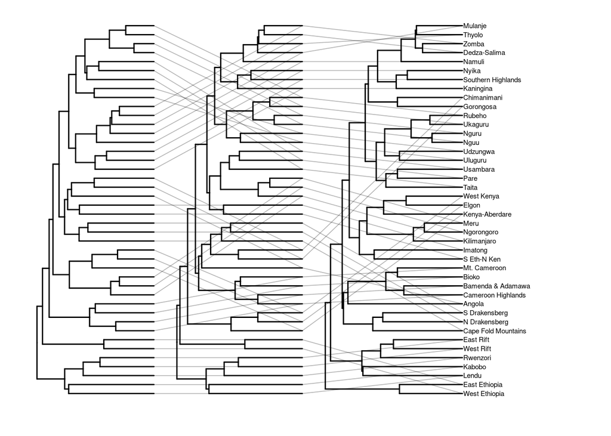

```r
z=read.tree(files[files%like%"Subspecies"&files%like%"Cooper"])
y=read.tree(files[files%like%"Subspecies"&files%like%"Bowie"])
x=read.tree(files[files%like%"Subspecies"&files%like%"Dowsett"])

z$tip.label=gsub("_"," ",z$tip.label)
x$tip.label=gsub("_"," ",x$tip.label)
y$tip.label=gsub("_"," ",y$tip.label)

x=fortify(x)
y=fortify(y)
z=fortify(z)

y$x=y$x+max(x$x)+1
z$x=z$x+max(y$x)+1

dd=bind_rows(x,y,z)%>%
  filter(!is.na(label))

p1=ggtree(x,layout='rectangular')
p2=geom_tree(data=y)
p3=geom_tree(data=z)
p4=geom_tiplab(data=z,size=2)
p5=geom_line(aes(x,y,group=label),data=dd,alpha=.3,size=0.3)
p6=xlim(c(0,max(z$x)+5))
p7=ylim(c(-0.5,max(z$y)))

plot1=p1+p2+p3+p4+p5+p6+p7
plot1
```

```r
ggsave(paste0(filepath,"Subspecies_compared.jpg"),
       plot = plot1,dpi = 400)
```

# 3 Overall Consensus Tree

```r
# read tree file
c.trees=list.files(filepath,pattern="*.consensus")

x=read.tree(paste0(filepath,"all_consensus.tre"))
x$tip.label=gsub("_"," ",x$tip.label)
x2=fortify(x)
```

Now, to plot the tree to view topology and to determine best format:

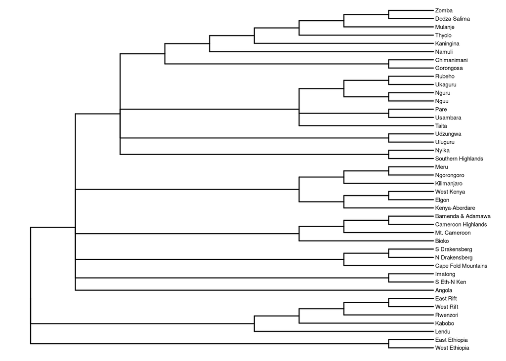

```r
p2=ggtree(x2,layout = "rectangular")+
  geom_tiplab(size=2)+
  scale_color_manual(values="black")+
  expand_limits(x=c(0,10))

print(p2)
```

For all authors, the topology is largely polytomies.

I am now looking at the consensus for Cooper:

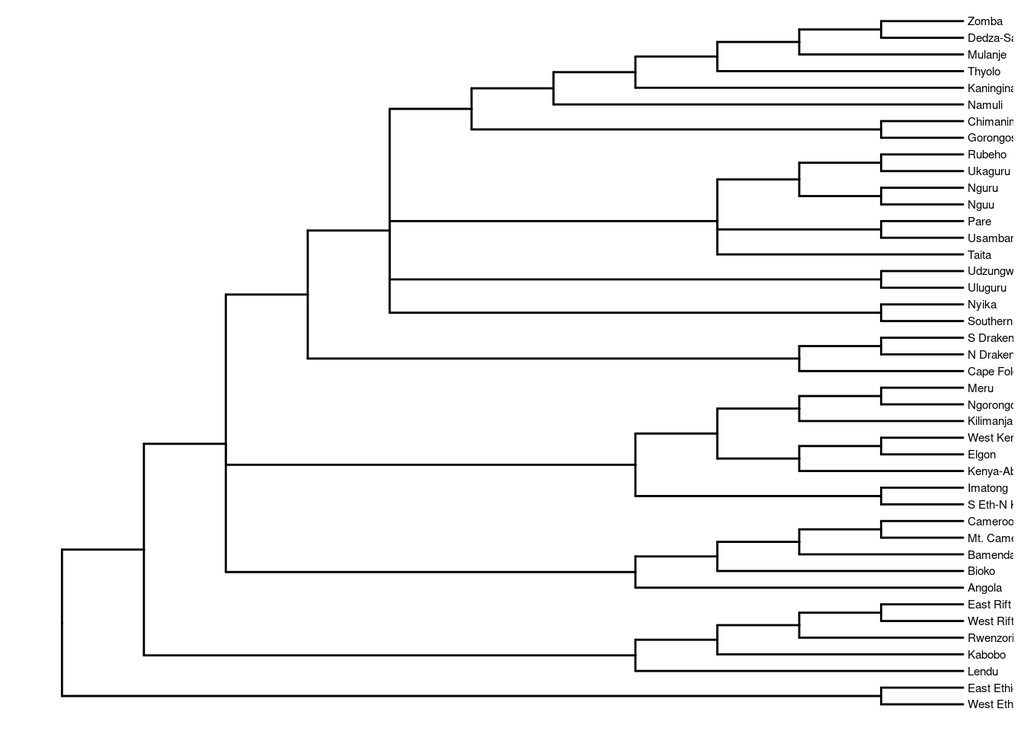

```r
x=read.tree(paste0(filepath,c.trees[which(c.trees%like%'Cooper')]))
x$tip.label=gsub("_"," ",x$tip.label)
x2=fortify(x)

p2=ggtree(x2,layout = "rectangular")+
  geom_tiplab(size=2)+
  scale_color_manual(values="black")+
  expand_limits(x=c(0,10))

print(p2)
```

We have more resolution with the Cooper tree, as is to be expected using the largest dataset.

Within this tree, multiple regions are supported by the multiple taxonomic levels. These regions are user-defined based on previous iterations and the topology of the dendrogram.

## 3.1 Clustering for 2021 list

We find good support for the Ethiopian Highlands and the Lacustrine Rift as being distinct. However, we have a double polytomy, with a three way polytomy of:

1. Cameroonian Highlands + Angola
2. Kenya-Tanzania Highlands
3. All remaining groups excepting the Lacustrine Rift and the Ethiopian Highlands

And within the all remaining groups subset, the Southern Great Escarpment is the outgroup to all others, which constitute a polytomy of the **Expanded Eastern Arc**:

1. Northern Eastern Arc
2. Central Eastern Arc (Udzungwa & Uluguru)
3. Southern Highlands & Nyika
4. Malawi-Mozambique Highlands (central Malawi to Chimanimani, Zimbabwe/Mozambique)

## 3.2 Data with satellite regions, for comparison

The following is the clustering as determined with satellite regions included for the 2021 list. *Note* this also includes a few other small edits (i.e., fixed distributions etc., especially with regards to the Southern Highlands, Tanzania).

1. Ethiopian Highlands
2. Lacustrine Rift (including Lendu, Kabobo)
3. Kenya-Tanzania Highlands
- Two subregions of Kenya-Uganda and N Tanzania

> Here is the first polytomy; denoted by $A$ after number.

4A. S Great Escarpment 5A. Cameroon Highlands 6A. Satellite Regions (including Angola) 7A. This branch leads to the second polytomy.

> Here is the second polytomy; denoted by $B$ after number. It should be noted some of these divisions are less extreme that divisions found within the satellite regions. This area can also be considered as the “expanded” Eastern Arc.

8B. Taita Hills 9B. C Eastern Arc - Uluguru, Udzungwa, Nyika, Mahenge, Iringa 10B. Malawi-Mozambique - closely allied outliers of Chimanimani/Gorongosa - S Malawian and Mozambican Highlands 11B. Other E Arc, with two subdivisions: - Pare & Usambara Mountains - Nguu, Nguru, Malundwe, Ukaguru, Rubeho

# Cooper Consensus Plot

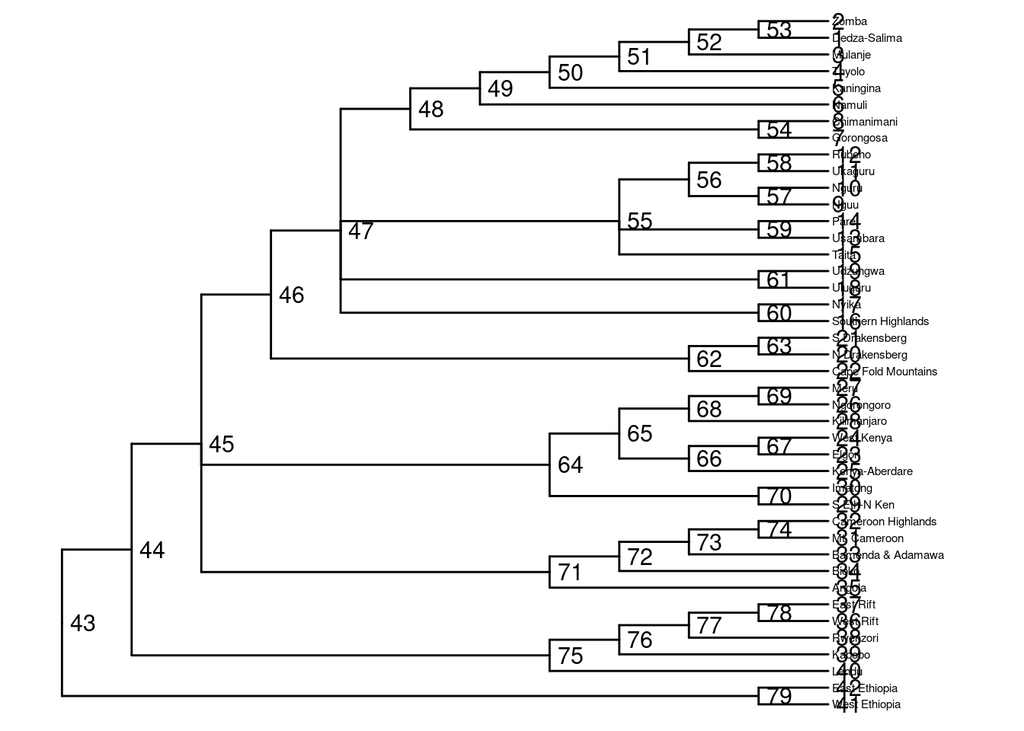

```r
# read tree file
z=x2

p2=ggtree(z,layout="rectangular")+
  geom_tiplab(size=2)+
  geom_text(aes(label=node),hjust=-.3,size=4)+
  #geom_text(aes(label=node),hjust=-.3)
  xlim(0,max(z$x)+2)#+
  #geom_nodepoint(color="black",
  #               size=(x2@phylo$node.label/25),
  #               shape="diamond")

print(p2)
```

While we find 6 major regions to be ideal looking at the topology of the tree, and comparing with the estimated number of groups using the ‘elbow method’, and comparing these results to other biogeographic results.

| Region | Node |
| --- | --- |
| Ethiopian Highlands | 79 |
| Lacustrine Rift | 75 |
| Cameroonian Highlands | 71 |
| Kenya-Tanzania Highlands | 64 |
| S Great Escarpment | 62 |
| Expanded Eastern Arc | 47 |

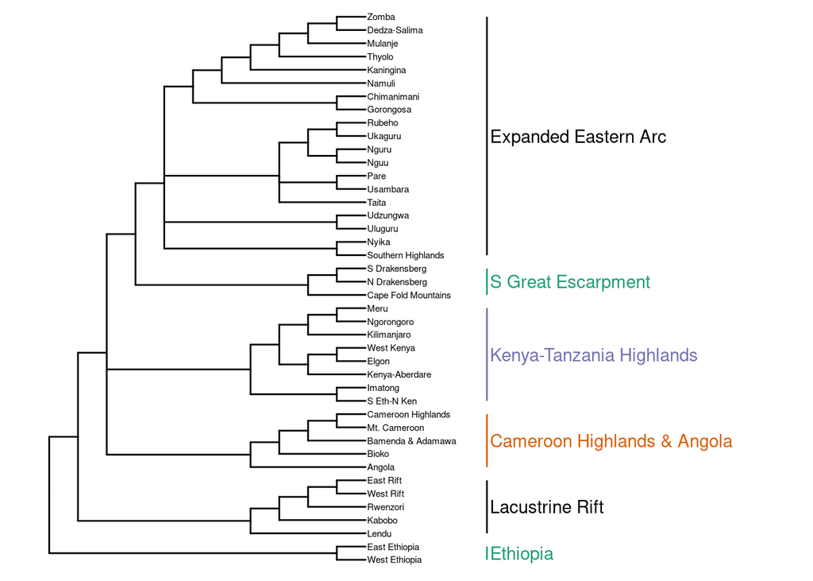

```r
offset=4

p2=ggtree(z,layout = "rectangular")+
  geom_tiplab(size=2)+
  scale_color_manual(values="black")+
  geom_cladelabel(node=79,align=T,offset=offset,color=x.colors[1],
                  label="Ethiopia")+
  geom_cladelabel(node=75,align=T,offset=offset,color=x.colors[2],
                  label="Lacustrine Rift")+
  geom_cladelabel(node=71,align=T,offset=offset,color=x.colors[3],
                  label="Cameroon Highlands & Angola")+
  geom_cladelabel(node=64,align=T,offset=offset,color=x.colors[4],
                  label="Kenya-Tanzania Highlands")+
  geom_cladelabel(node=62,align=T,offset=offset,color=x.colors[1],
                  label="S Great Escarpment")+
  geom_cladelabel(node=47,align=T,offset=offset,color=x.colors[2],
                  label="Expanded Eastern Arc")+
  #geom_cladelabel(node=75,align=T,offset=offset,color=x.colors[4],
  #                label="Cameroonian Highlands")+
  #geom_cladelabel(node=23,align=T,offset=offset,color=x.colors[1],
  #                label="Angola")+
  #geom_cladelabel(node=80,align=T,offset=offset,color=x.colors[2],
  #                label="Core Eastern Arc",fontsize=2.5)+
  #geom_cladelabel(node=92,align=T,offset=offset,color=x.colors[3],
  #                label="S Eastern Arc & Satellite Regions")+
  #geom_text(aes(label=node),hjust=-.3)
  expand_limits(x=c(0,25))#+
  #geom_nodepoint(color="black",
  #               size=(x2@phylo$node.label/25),
  #               shape="diamond")

print(p2)
```

```r
ggsave(p2,filename=paste0(output,"Cooper_consensus.png"),dpi=400)
```

We can also compare all consensuses.

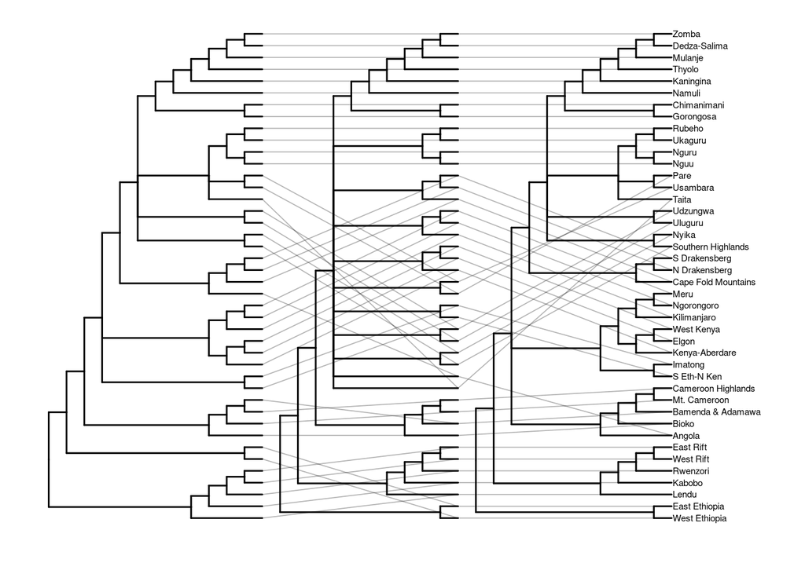

```r
c.trees=paste0(filepath,c.trees)

z=read.tree(c.trees[c.trees%like%"Cooper"])
y=read.tree(c.trees[c.trees%like%"Bowie"])
x=read.tree(c.trees[c.trees%like%"Dowsett"])

z$tip.label=gsub("_"," ",z$tip.label)
x$tip.label=gsub("_"," ",x$tip.label)
y$tip.label=gsub("_"," ",y$tip.label)

x=fortify(x)
y=fortify(y)
z=fortify(z)

y$x=y$x+max(x$x)+1
z$x=z$x+max(y$x)+1

dd=bind_rows(x,y,z)%>%
  filter(!is.na(label))

p1=ggtree(x,layout='rectangular')
p2=geom_tree(data=y)
p3=geom_tree(data=z)
p4=geom_tiplab(data=z,size=2)
p5=geom_line(aes(x,y,group=label),data=dd,alpha=.3,size=0.3)
p6=xlim(c(0,max(z$x)+5))
p7=ylim(c(-0.5,max(z$y)))

plot1=p1+p2+p3+p4+p5+p6+p7
plot1
```

```r
ggsave(paste0(filepath,"Consensus_compared.jpg"),
       plot = plot1,dpi = 400)
```